# Integration site summary

Wed 28 Jul 2021

## Overview

The goal of integration site analysis with *isling* is to identify host/virus jucntions in sequence datas. These host/virus junctions are evidence for viral integration into a host genome. The main steps in integration site analysis with *isling* are shown below:

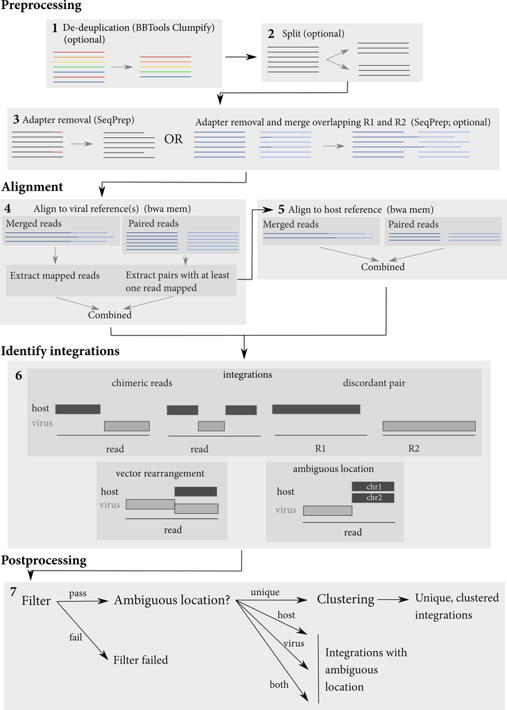

Overview of the steps for identifying integrations

## Datasets

First, an overview of the datasets analysed:

| dataset | n | host | virus |
| --- | --- | --- | --- |
| AGRF_CAGRF20124957_JC8BL | 19 | GRCh38 | pAAV2-OTC_flop |
| AGRF_CAGRF21025364_JJ47P | 12 | GRCh38 | pAAV2-OTC_flop |

## Number of host/virus junctions identified

Isling identifies host/virus junctions in chimeric reads and discordant pairs. First, looking at the total number of junctions identified in each dataset. Note that at first, we count all identified junctions

First, count the number of host/virus junctions identified in chimeric reads or discordant read-pairs.

| dataset | junctions passing filters | total putative junctions | junctions failing filters |
| --- | --- | --- | --- |
| AGRF_CAGRF20124957_JC8BL | 24316 | 256153 | 231837 |
| AGRF_CAGRF21025364_JJ47P | 50252 | 353424 | 303172 |

.

## Junction types

For this section, we examine all the integration junctions retained after filtering. Each junction has a number of properties associated with it. In this section we examine some of those properties.

### Chimeric reads and discordant pairs

Counting the number of junctions that were observed in chimeric reads and discordant pairs. For chimeric reads, we further stratify in the junction had a ‘gap’, ‘overlap’ or was a ‘clean’ junction.

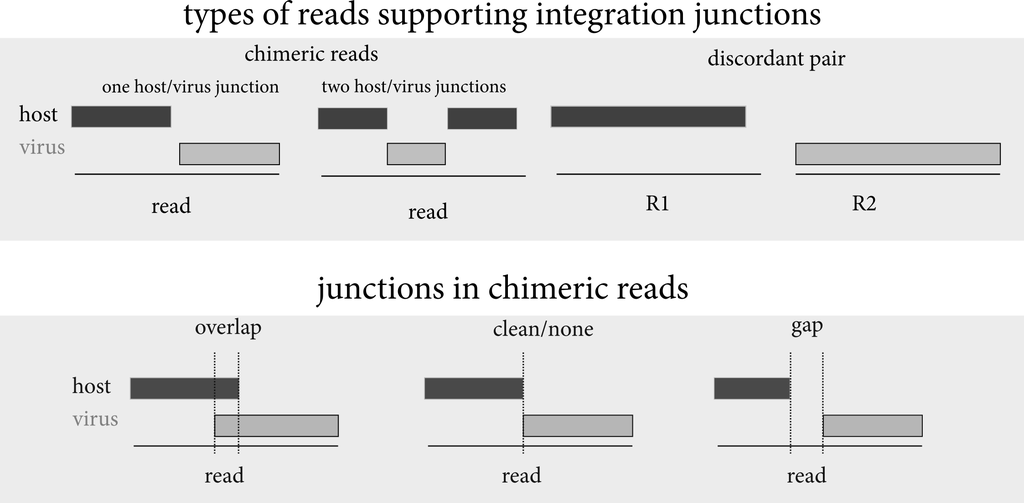

Types of reads supporting integration junctions and junction types

We call any bases involved in a gap or overlap ‘ambiguous bases’, and since it is not possible to identify a precise location within those ambiguous bases, *isling* reports the coordinates of the bases as the location of the integration.

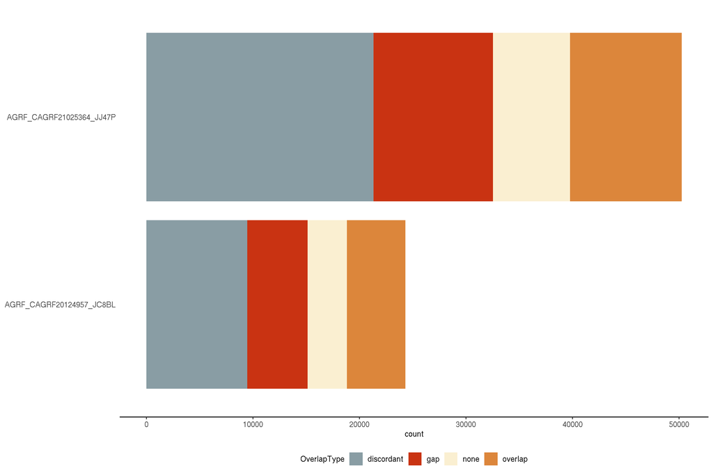

If the junction is ‘gap’ or ‘overlap’, it has an associated number of ambiguous bases associated with it. The distribution of the number of ambiguous bases looks like this (note that this frequency polynomial is normalised so the area under each curve is the same for all datasets)

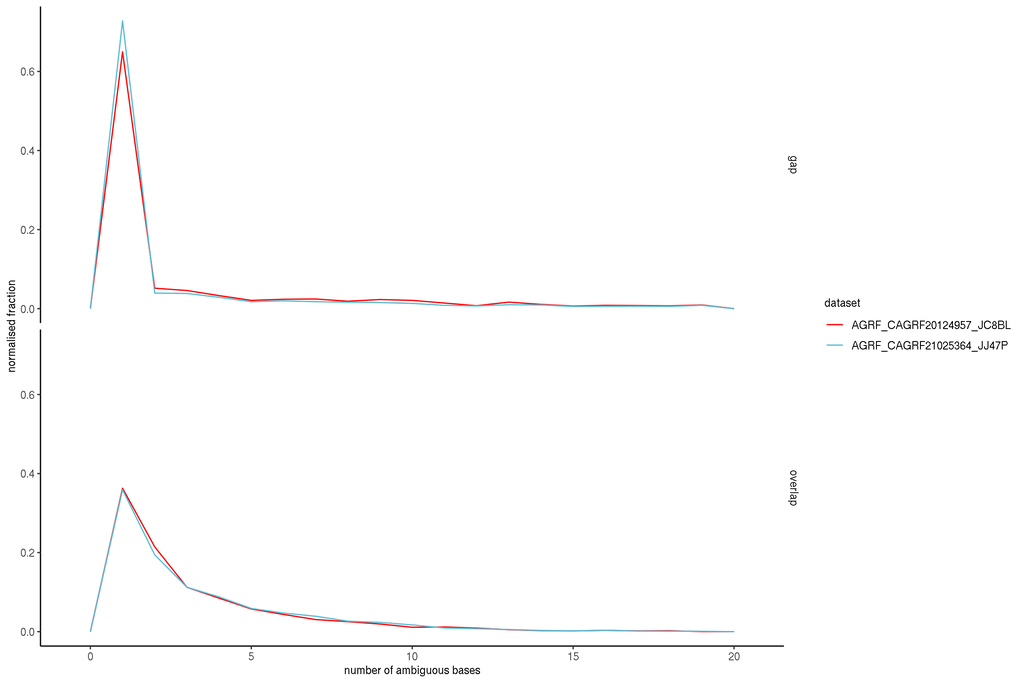

### Ambiguous/unique locations

We can also count the number of junctions that can be uniquely localised in both host and virus genomes, and those with locations that are ambiguous in one or both genomes.

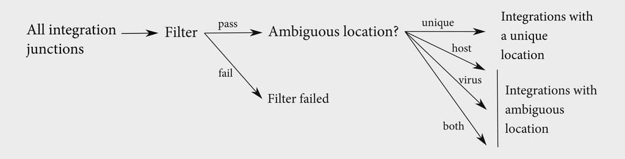

Post-processing steps

Note the distinction between ‘ambiguous bases’, which refer to the bases that are part of a gap or overlap at an individual integration junction, and ‘ambiguous location’, which refers to host or viral alignments which cannot be uniquely localised in the respective genome. These ambiguous locations occur because the mapping quality of the alignment is low, or because there are multiple best alignments for the read.

We divide integrations into four groups, depending on their locations in host and viral references:

| Group | Host location | Virus location |
| --- | --- | --- |
| Unique | Unambiguous | Unambiguous |
| Ambiguous (host) | Ambiguous | Unambiguous |
| Ambiguous (virus) | Unambiguous | Ambiguous |
| Ambiguous (both) | Ambiguous | Ambiguous |

Counting the number of junctions in each of these four groups:

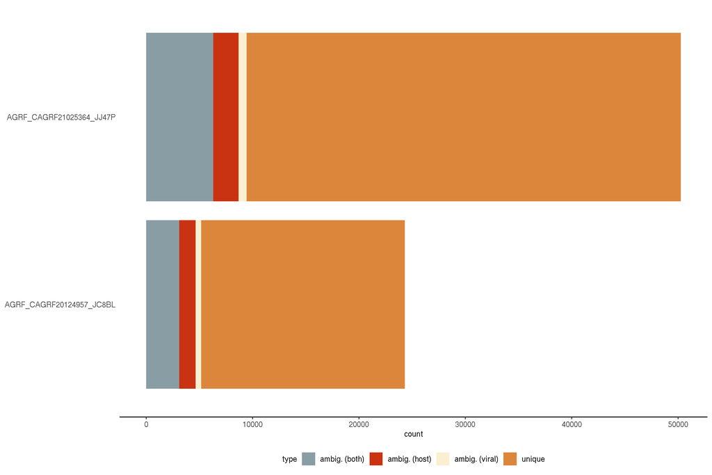

## Junction locations

Next, examine the location of identified integration locations in both host and vector.

### Location in host reference(s)

We can also plot the location of the integrations for datasets aligned to the host genome GRCh38.

These are the datasets:

- `AGRF_CAGRF20124957_JC8BL`
- `AGRF_CAGRF21025364_JJ47P`

Here we’re onlyl interested in jucntions with an unambiguous location in the host genome, i.e. the ‘unique’ group and the ‘ambiguous location (virus)’ group.

We first plot the number of integration junctions identified in each contig in the host reference.

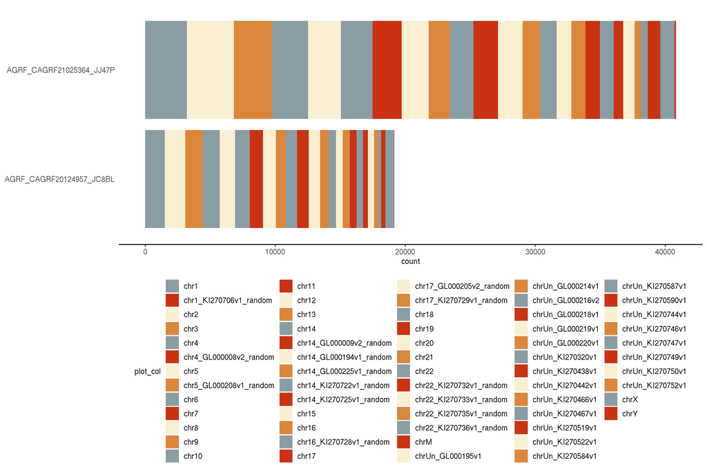

Next, we look at the 25 contigs with the most integrations, and plot the locatioin of the integrations within those contigs.

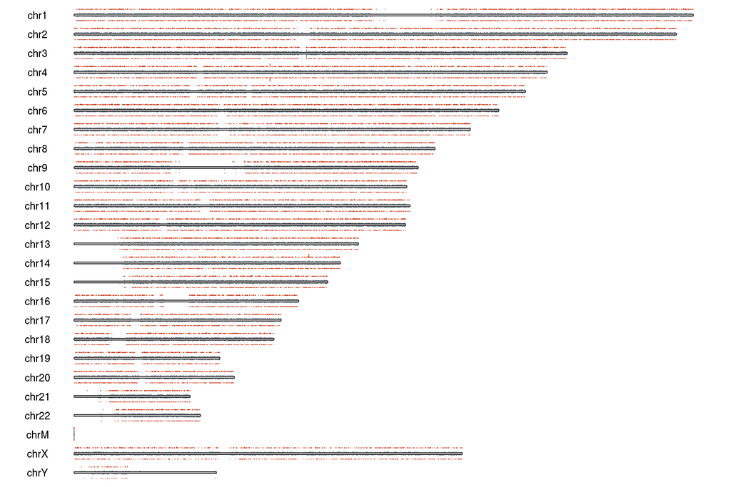

### Location in viral reference(s)

We can also plot the location of the integrations for datasets aligned to the viral genome pAAV2-OTC_flop.

These are the datasets:

- `AGRF_CAGRF20124957_JC8BL`
- `AGRF_CAGRF21025364_JJ47P`

Here we’re onlyl interested in jucntions with an unambiguous location in the virus genome, i.e. the ‘unique’ group and the ‘ambiguous location (host)’ group.

We first plot the number of integration junctions identified in each contig in the virus reference.

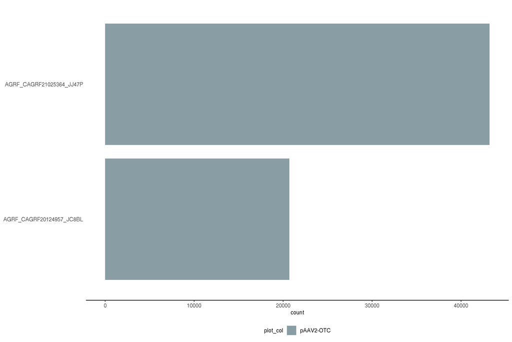

Next, we look at the 25 contigs with the most integrations, and plot the locatioin of the integrations within those contigs.

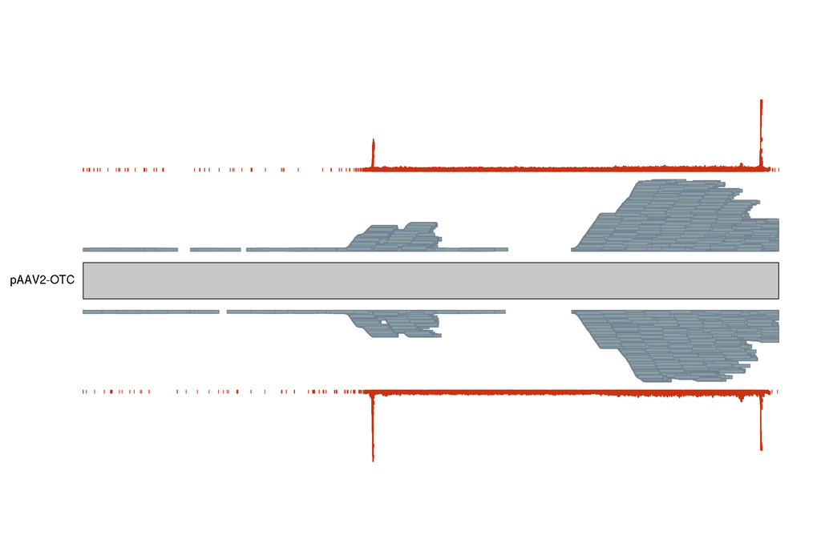